# Part I - 201902- Fordgobike Tripdata

## Introduction

> This dataset includes information on individual rides made in a bike-sharing system covering the Greater San Francisco Bay Area during the month of February 2019.

## Preliminary Wrangling

```python
# import all packages and set plots to be embedded inline
import numpy as np
import pandas as pd
import matplotlib.pyplot as plt
import seaborn as sb

%matplotlib inline
```

```python
# load in the dataset into a pandas dataframe
bikedata = pd.read_csv('201902-fordgobike-tripdata.csv')
```

```python
# high-level overview of data shape and composition
print(bikedata.shape)
print(bikedata.dtypes)
```

```
(183412, 16)
duration_sec                 int64
start_time                  object
end_time                    object
start_station_id           float64
start_station_name          object
start_station_latitude     float64
start_station_longitude    float64
end_station_id             float64
end_station_name            object
end_station_latitude       float64
end_station_longitude      float64
bike_id                      int64
user_type                   object
member_birth_year          float64
member_gender               object
bike_share_for_all_trip     object
dtype: object
```

```python
bikedata.head()
```

|  | duration_sec | start_time | end_time | start_station_id | start_station_name | start_station_latitude | start_station_longitude | end_station_id | end_station_name | end_station_latitude | end_station_longitude | bike_id | user_type | member_birth_year | member_gender | bike_share_for_all_trip |
| --- | --- | --- | --- | --- | --- | --- | --- | --- | --- | --- | --- | --- | --- | --- | --- | --- |
| 0 | 52185 | 2019-02-28 17:32:10.1450 | 2019-03-01 08:01:55.9750 | 21.0 | Montgomery St BART Station (Market St at 2nd St) | 37.789625 | -122.400811 | 13.0 | Commercial St at Montgomery St | 37.794231 | -122.402923 | 4902 | Customer | 1984.0 | Male | No |
| 1 | 42521 | 2019-02-28 18:53:21.7890 | 2019-03-01 06:42:03.0560 | 23.0 | The Embarcadero at Steuart St | 37.791464 | -122.391034 | 81.0 | Berry St at 4th St | 37.775880 | -122.393170 | 2535 | Customer | NaN | NaN | No |
| 2 | 61854 | 2019-02-28 12:13:13.2180 | 2019-03-01 05:24:08.1460 | 86.0 | Market St at Dolores St | 37.769305 | -122.426826 | 3.0 | Powell St BART Station (Market St at 4th St) | 37.786375 | -122.404904 | 5905 | Customer | 1972.0 | Male | No |
| 3 | 36490 | 2019-02-28 17:54:26.0100 | 2019-03-01 04:02:36.8420 | 375.0 | Grove St at Masonic Ave | 37.774836 | -122.446546 | 70.0 | Central Ave at Fell St | 37.773311 | -122.444293 | 6638 | Subscriber | 1989.0 | Other | No |
| 4 | 1585 | 2019-02-28 23:54:18.5490 | 2019-03-01 00:20:44.0740 | 7.0 | Frank H Ogawa Plaza | 37.804562 | -122.271738 | 222.0 | 10th Ave at E 15th St | 37.792714 | -122.248780 | 4898 | Subscriber | 1974.0 | Male | Yes |

```python
bikedata.isnull().sum()
```

```
duration_sec                  0
start_time                    0
end_time                      0
start_station_id            197
start_station_name          197
start_station_latitude        0
start_station_longitude       0
end_station_id              197
end_station_name            197
end_station_latitude          0
end_station_longitude         0
bike_id                       0
user_type                     0
member_birth_year          8265
member_gender              8265
bike_share_for_all_trip       0
dtype: int64
```

```python
print(bikedata.member_birth_year.min())
print(bikedata.member_birth_year.max())
```

```
1878.0
2001.0
```

#### Issues

Quality

- start_time, end_time are object should be datetime
- start_station_id, end_station_id are float should be str
- bike_id is int should be str
- member_birth_year is float should be int
- user_type, member_gender should be categorical types
- nan rows for stations should be deleted
- rows where calculated 'age' is more than 90 should be deleted

  Tidyness
- age field calculated on member_birth_year should be added
- start_day and end_day

#### Treatment

Define

- Datatypes issues fixing

Code

```python
# 1 start_time, end_time are object  should be datetime
bikedata['start_time'] = pd.to_datetime(bikedata['start_time'])
bikedata['end_time'] = pd.to_datetime(bikedata['end_time'])
```

```python
# 2 start_station_id, end_station_id are float  should be str
bikedata['start_station_id'] = bikedata['start_station_id'].astype(str)
bikedata['end_station_id'] = bikedata['end_station_id'].astype(str)
```

```python
bikedata['start_station_id'] = bikedata['start_station_id'].str[:-2]
bikedata['end_station_id'] = bikedata['end_station_id'].str[:-2]
```

```python
# 3 bike_id is int should be str
bikedata['bike_id'] = bikedata['bike_id'].astype(str)
```

```python
# 4 member_birth_year is float should be int
bikedata.member_birth_year.fillna(0,inplace=True)
bikedata['member_birth_year'] = bikedata['member_birth_year'].astype(int)
```

```python
# 5 convert user_type, member_gender into categorical types
ordinal_var_dict = {'user_type': ['Customer','Subscriber'],
                    'member_gender': ['Male','Female','Other']}

for var in ordinal_var_dict:
    ordered_var = pd.api.types.CategoricalDtype(ordered = True,
                                                categories = ordinal_var_dict[var])
    bikedata[var] = bikedata[var].astype(ordered_var)
```

Test

```python
bikedata.dtypes
```

```
duration_sec                        int64
start_time                 datetime64[ns]
end_time                   datetime64[ns]
start_station_id                   object
start_station_name                 object
start_station_latitude            float64
start_station_longitude           float64
end_station_id                     object
end_station_name                   object
end_station_latitude              float64
end_station_longitude             float64
bike_id                            object
user_type                        category
member_birth_year                   int32
member_gender                    category
bike_share_for_all_trip            object
dtype: object
```

Define

- Nan rows fixing

Code

```python
bikedata.dropna(subset=['start_station_name'], inplace=True)
```

Test

```python
bikedata.isnull().sum()
```

```
duration_sec                  0
start_time                    0
end_time                      0
start_station_id              0
start_station_name            0
start_station_latitude        0
start_station_longitude       0
end_station_id                0
end_station_name              0
end_station_latitude          0
end_station_longitude         0
bike_id                       0
user_type                     0
member_birth_year             0
member_gender              8263
bike_share_for_all_trip       0
dtype: int64
```

Define

- age field calculated on member_birth_year

Code

```python
bikedata['age'] = 2019 - bikedata.member_birth_year
bikedata.age.replace(2019,0,inplace= True)
```

Test

```python
bikedata.head(3)
```

|  | duration_sec | start_time | end_time | start_station_id | start_station_name | start_station_latitude | start_station_longitude | end_station_id | end_station_name | end_station_latitude | end_station_longitude | bike_id | user_type | member_birth_year | member_gender | bike_share_for_all_trip | age |
| --- | --- | --- | --- | --- | --- | --- | --- | --- | --- | --- | --- | --- | --- | --- | --- | --- | --- |
| 0 | 52185 | 2019-02-28 17:32:10.145 | 2019-03-01 08:01:55.975 | 21 | Montgomery St BART Station (Market St at 2nd St) | 37.789625 | -122.400811 | 13 | Commercial St at Montgomery St | 37.794231 | -122.402923 | 4902 | Customer | 1984 | Male | No | 35 |
| 1 | 42521 | 2019-02-28 18:53:21.789 | 2019-03-01 06:42:03.056 | 23 | The Embarcadero at Steuart St | 37.791464 | -122.391034 | 81 | Berry St at 4th St | 37.775880 | -122.393170 | 2535 | Customer | 0 | NaN | No | 0 |
| 2 | 61854 | 2019-02-28 12:13:13.218 | 2019-03-01 05:24:08.146 | 86 | Market St at Dolores St | 37.769305 | -122.426826 | 3 | Powell St BART Station (Market St at 4th St) | 37.786375 | -122.404904 | 5905 | Customer | 1972 | Male | No | 47 |

Define

- rows where calculated 'age' is more than 90 should be deleted

Code

```python
bikedata = bikedata.query('age < 90')
```

Test

```python
(bikedata.age>90).sum()
```

```
0
```

Define

- add start_day, end_day

Code

```python
bikedata['start_day'] = bikedata['start_time'].dt.day_name()
bikedata['end_day'] = bikedata['end_time'].dt.day_name()
```

Test

```python
bikedata.head(1)
```

|  | duration_sec | start_time | end_time | start_station_id | start_station_name | start_station_latitude | start_station_longitude | end_station_id | end_station_name | end_station_latitude | end_station_longitude | bike_id | user_type | member_birth_year | member_gender | bike_share_for_all_trip | age | start_day | end_day |
| --- | --- | --- | --- | --- | --- | --- | --- | --- | --- | --- | --- | --- | --- | --- | --- | --- | --- | --- | --- |
| 0 | 52185 | 2019-02-28 17:32:10.145 | 2019-03-01 08:01:55.975 | 21 | Montgomery St BART Station (Market St at 2nd St) | 37.789625 | -122.400811 | 13 | Commercial St at Montgomery St | 37.794231 | -122.402923 | 4902 | Customer | 1984 | Male | No | 35 | Thursday | Friday |

```python
bikedata.info()
```

```
<class 'pandas.core.frame.DataFrame'>
Int64Index: 183138 entries, 0 to 183411
Data columns (total 19 columns):
 #   Column                   Non-Null Count   Dtype
---  ------                   --------------   -----
 0   duration_sec             183138 non-null  int64
 1   start_time               183138 non-null  datetime64[ns]
 2   end_time                 183138 non-null  datetime64[ns]
 3   start_station_id         183138 non-null  object
 4   start_station_name       183138 non-null  object
 5   start_station_latitude   183138 non-null  float64
 6   start_station_longitude  183138 non-null  float64
 7   end_station_id           183138 non-null  object
 8   end_station_name         183138 non-null  object
 9   end_station_latitude     183138 non-null  float64
 10  end_station_longitude    183138 non-null  float64
 11  bike_id                  183138 non-null  object
 12  user_type                183138 non-null  category
 13  member_birth_year        183138 non-null  int32
 14  member_gender            174875 non-null  category
 15  bike_share_for_all_trip  183138 non-null  object
 16  age                      183138 non-null  int32
 17  start_day                183138 non-null  object
 18  end_day                  183138 non-null  object
dtypes: category(2), datetime64[ns](2), float64(4), int32(2), int64(1), object(8)
memory usage: 24.1+ MB
```

```python
# Save clean data
bikedata.to_csv('clean_dataset.csv',index=False)
```

### What is the structure of your dataset?

> There are 183,138 bikes sharing entries from February 1st and 28th 2019 which records.
- Duration of the trip in seconds
- Start and End timestamps (date/hour)
- Start and End Stations names, gps coordinates and id
- Bike id number
- Type of user (whether the user is a subscriber or customer)
- Various personal data (Gender / Birth Year)
- Bike share for all trip which is an affordable pricing plan option
- Age (added column) of user
- Start and End days (added columns)

  > Most variables are numeric in nature, but the variables user_type, member_gender, and Bike_share_for_all_trip are categorical variables.

### What is/are the main feature(s) of interest in your dataset?

> I'm most interested in figuring out how the duration is affected by other variables.

### What features in the dataset do you think will help support your investigation into your feature(s) of interest?

> I expect that weekdays, member_gender, user_type, age will have main effects on the duration. I also think that the hours, will have effects on duration.

## Univariate Exploration

I'll start by looking at the distribution of the main variable of interest: duration.

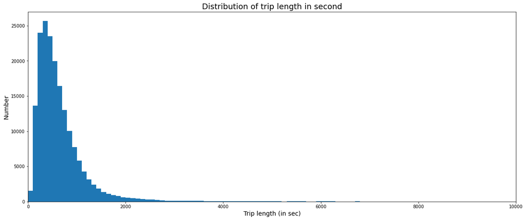

```python
binsize=100
bins = np.arange(0,bikedata['duration_sec'].max()+binsize, binsize)

plt.figure(figsize=(20,8))

plt.hist(data=bikedata, x='duration_sec', bins=bins)

plt.title('Distribution of trip length in second', size=(18))
plt.xlabel('Trip length (in sec)', size=14)
plt.ylabel('Number', size=14)
plt.xlim(0,10000);
```

The distribution of trip durations in second seems to be Right-skewed at first with a peak between 0 and 500. There's a long tail in the distribution, so let's put it on a log scale instead

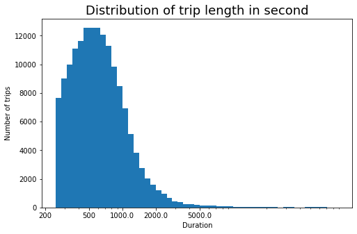

```python
log_binsize = 0.05
bins = 10 ** np.arange(2.4, np.log10(bikedata['duration_sec'].max())+log_binsize, log_binsize)

plt.figure(figsize=[8,5])
plt.hist(data = bikedata, x = 'duration_sec', bins = bins)
plt.xscale('log')
tick_locs = [200, 500, 1e3, 2e3, 5e3]
plt.xticks(tick_locs, tick_locs)
plt.xlabel('Duration')
plt.ylabel('Number of trips')
plt.title('Distribution of trip length in second', size=(18))
plt.show()
```

Next up, the first predictor variable of interest: weekdays.

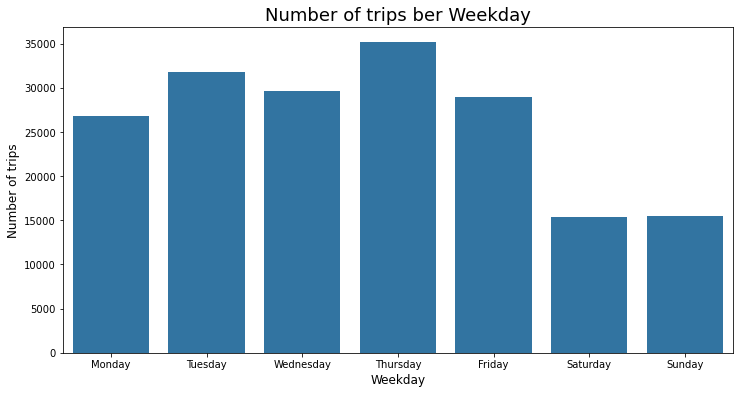

```python
plt.figure(figsize=(12,6))

color = sb.color_palette()[0]
sb.countplot(data=bikedata, x='start_day', order=['Monday', 'Tuesday', 'Wednesday', 'Thursday', 'Friday', 'Saturday', 'Sunday'], color=color)

plt.title('Number of trips ber Weekday', size=(18))
plt.xlabel('Weekday', size=12)
plt.ylabel('Number of trips', size=12)
```

Next predictor variable of interest: member_gender.

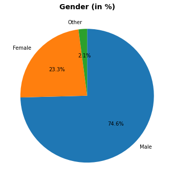

```python
plt.figure(figsize=[8,6])

counts = bikedata['member_gender'].value_counts()
plt.pie(counts, labels = counts.index,
        autopct='%1.1f%%',shadow=False, startangle = 90,counterclock = False)
plt.title('Gender (in %)', fontsize=14, fontweight='bold');
```

> Observation: The users are in majority Males around 3/4 of total (74,6%)

Next predictor variable of interest: user_type.

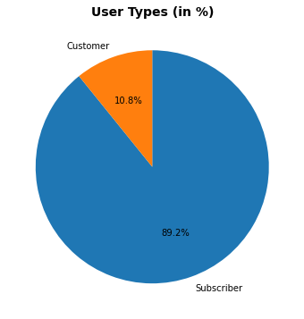

```python
plt.figure(figsize=[8,6])

counts = bikedata['user_type'].value_counts()
plt.pie(counts, labels = counts.index,
        autopct='%1.1f%%',shadow=False, startangle = 90,counterclock = False)
plt.title('User Types (in %)', fontsize=14, fontweight='bold');
```

> Observation: A vast majority (89,2%) of the users are Subscribers to GoBike

Next predictor variable of interest: age.

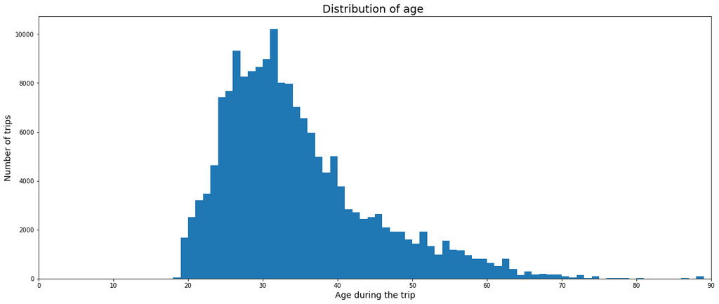

```python
bins=np.arange(15,90+1,1)

plt.figure(figsize=(20,8))
plt.hist(data=bikedata, x='age',bins=bins);
plt.xlabel('Age during the trip', size=14)
plt.ylabel('Number of trips', size=14)
plt.title('Distribution of age ', size=(18))
plt.xlim(0,90);
```

> Observation: We can see that a majority of the users are between 20 and 40 years old.

### Of the features you investigated, were there any unusual distributions? Did you perform any operations on the data to tidy, adjust, or change the form of the data? If so, why did you do this?

> The distribution of trip durations had to be plotted on a logarithmic scale to looks more like a normal distribution.

## Bivariate Exploration

To begin with, let's look at the relationship between the entities in the data.

```python
# let's filter trips duration under 5500s
filtered  = bikedata.query('duration_sec < 5500')
```

1- duration vs weekday

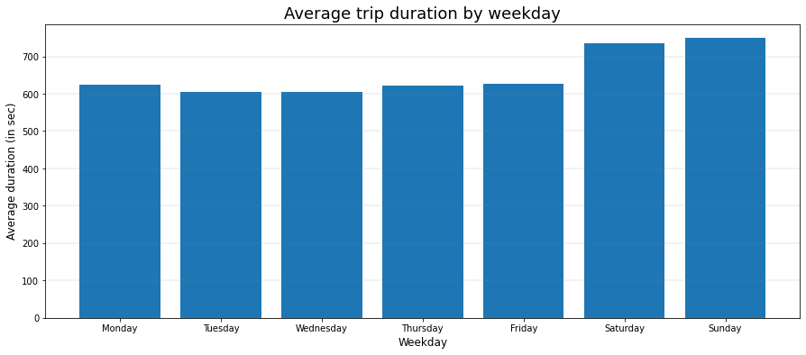

```python
plt.figure(figsize=(15,6))
avg_min_duration_weekday = filtered.groupby('start_day')['duration_sec'].mean().reindex(['Monday', 'Tuesday', 'Wednesday', 'Thursday', 'Friday', 'Saturday', 'Sunday']).reset_index()

plt.bar(avg_min_duration_weekday['start_day'],avg_min_duration_weekday['duration_sec'], color='#1e77b4')

plt.title('Average trip duration by weekday', size=(18))
plt.xlabel('Weekday', size=12)
plt.ylabel('Average duration (in sec)', size=12)
plt.grid(color='grey', axis='y', linestyle='-', linewidth=0.2);
```

> Observation: Though the amount of trips are more important in week days compared to weekends (as seen previously), they seem to be longer on average on Sundays and Saturdays

Let's move on to looking at how duration correlate with the categorical variables.

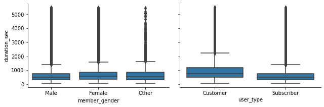

```python
def boxgrid(x, y, **kwargs):
    """ Quick hack for creating box plots with seaborn's PairGrid. """
    default_color = sb.color_palette()[0]
    sb.boxplot(x, y, color = default_color)

plt.figure(figsize = [10, 10])
g = sb.PairGrid(data = filtered, y_vars = ['duration_sec', ], x_vars = ['member_gender','user_type'],
                size = 3, aspect = 1.5)
g.map(boxgrid)
plt.show();
```

> Observation: The above plots show that all genders have a rather similar average trip durations. However, we saw earlier that users of the services were in 3/4 Males, but gender really doesn't affects duration. Plots also show that Customers have a Median of trip duration higher than the 3rd quartile of Subscribers. It suggests that user type have a impact on trip durations

let's look at relationships between the categorical features.

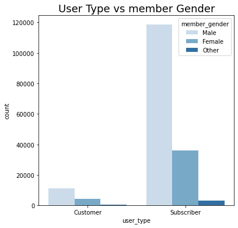

```python
plt.figure(figsize = [6, 6])
sb.countplot(data = filtered, x = 'user_type', hue = 'member_gender', palette = 'Blues')
plt.title('User Type vs member Gender', size=(18))
plt.show()
```

For customers or subscribers, most of users are males

Let's look relationship between duration and bike_share_for_all_trip

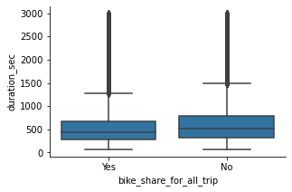

```python
plt.figure(figsize = [10, 10])
g = sb.PairGrid(data = filtered.query('duration_sec <  3000'), y_vars = ['duration_sec', ], x_vars = ['bike_share_for_all_trip'],
                size = 3, aspect = 1.5)
g.map(boxgrid)
plt.show();
```

Our plot show that we have longer trip duration for bikes not shared for all trip  
Let's find relationship between bike_share_for_all_trip and user_type

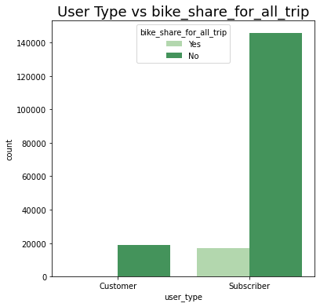

```python
plt.figure(figsize = [6, 6])

sb.countplot(data = filtered, x = 'user_type', hue = 'bike_share_for_all_trip', palette = 'Greens')
plt.title('User Type vs bike_share_for_all_trip', size=(18))
plt.show()
```

> Observation: We can see that users generally opt for No bike share for all trip and only subscribers seem to have some Yes.

Let's finally find how duration correlate with hours of trips

[output not shown]

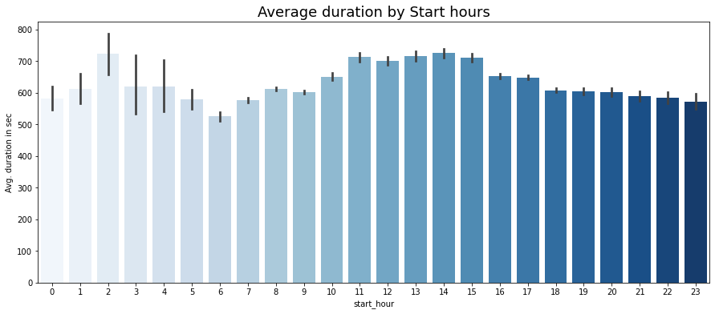

```python
filtered['start_hour'] = filtered['start_time'].dt.hour
plt.figure(figsize=(15,6))
sb.barplot(data = filtered, x = 'start_hour', y = 'duration_sec',
            palette=  'Blues')
plt.ylabel('Avg. duration in sec')
plt.title('Average duration by Start hours', size=(18))
plt.show()
```

### Did you observe any interesting relationships between the other features (not the main feature(s) of interest)?

> We see that bikes are used more on weekdays than on weekends, the majority of users are subscribers. And bike share option is sometimes chosen by subscribers

## Multivariate Exploration

> Create plots of three or more variables to investigate your data even further. Make sure that your investigations are justified, and follow from your work in the previous sections.

let's Create faceted heat maps on weekdays

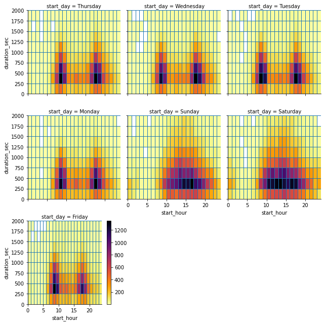

```python
xbin = np.arange(0,24+1,1)
ybin = np.arange(0,2000+250,250)
g = sb.FacetGrid (data = filtered , col='start_day',col_wrap=3,height=3)
g.map(plt.hist2d, 'start_hour', 'duration_sec', cmin=0.5, cmap = 'inferno_r', bins=[xbin,ybin])
plt.colorbar();
```

How the duration of trips varies according to weekdays for users

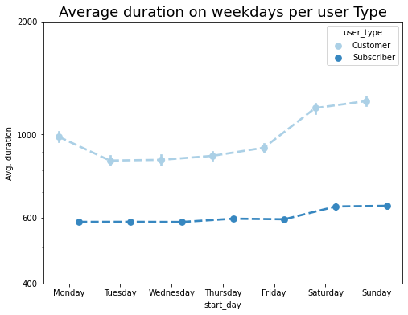

```python
fig = plt.figure(figsize = [8,6])
ax = sb.pointplot(data = filtered, x = 'start_day', y = 'duration_sec', hue = 'user_type',
           palette = 'Blues', linestyles = '--', dodge = 0.4,order=[ 'Monday', 'Tuesday', 'Wednesday', 'Thursday', 'Friday', 'Saturday', 'Sunday'])
plt.ylabel('Avg. duration')
plt.yscale('log')
plt.yticks([4e2, 6e2, 1e3,2e3], ['400', '600', '1000','2000'])
ax.set_yticklabels([],minor = True)
plt.title('Average duration on weekdays per user Type', size=(18))
plt.show();
```

> Observation: Daily trip duration for customers are longer than subscribers.Both subscribers and customers take longer trips during weekend than weekdays. Customers take longer trips during the weekend.

We can try to also how the duration of trips varies according to hours for users

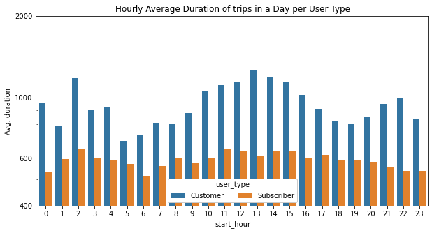

```python
plt.figure(figsize = (10, 5))
ax = sb.barplot(data = filtered, x = 'start_hour', y = 'duration_sec', hue = 'user_type', errwidth = 0)
ax.legend(loc = 8, ncol = 3, framealpha = 1, title = 'user_type')
plt.ylabel('Avg. duration')
plt.yscale('log')
plt.yticks([4e2, 6e2, 1e3,2e3], ['400', '600', '1000','2000'])
ax.set_yticklabels([],minor = True)
plt.title('Hourly Average Duration of trips in a Day per User Type');
```